# Reviewing : Julie’s answers

```r
library(CTexploreR)
library(tidyverse)
library(readxl)
library(GenomicRanges)
library(SummarizedExperiment)
library(biomaRt)

CT_genes <- CT_genes %>%
  filter(CT_gene_type == "CT_gene")

CT_genes <- CT_genes %>%
  mutate(group = ifelse(regulated_by_methylation, "MethDep", "Non-MethDep"))
MethDep_colors <- c("MethDep" = "indianred2", "Non-MethDep"= "cyan4")
all_groups_colors <- c("X-linked Methdep CG" = "indianred2", "Non-Methdep CG"= "cyan4",
                      "Not X Methdep CG" = "darksalmon", "Autosomal other" = "gray30",
                      "X-linked other" = "gray30")
```

# Review 1.1

*Comprehensive functional characterization of cancer-testis antigens defines obligate participation in multiple hallmarks of cancer. Maxfield KE, Taus PJ, Corcoran K, Wooten J, Macion J, Zhou Y, Borromeo M, Kollipara RK, Yan J, Xie Y, Xie XJ, Whitehurst AW. Nat Commun. 2015 Nov 16;6:8840. doi: 10.1038/ncomms9840. PMID: 26567849*

What does that mean ? I can compare the genes they got out with CTexploreR

Suppl data 1 : 140 CTA with documented expression in solid tumors were analysed

```r
Maxwell_suppl1 <- read_excel("data/Maxwell_suppl1.xlsx")
Maxwell_suppl1_gene_names <- Maxwell_suppl1$`Gene Name`[!is.na(Maxwell_suppl1$`Gene Name`)]
# length(Maxwell_suppl1_gene_names)
```

They mention 140 genes but there’s only 102 lines in their file, that’s because of how they wrote the gene names. I’m still comparing what I have here but am not taking the time to clean.

Let’s look at those genes in CTexploreR

```r
all_genes %>%
  filter(external_gene_name %in% Maxwell_suppl1_gene_names)
```

| ensembl_gene_id | external_gene_name | CT_gene_type | testis_specificity | regulated_by_methylation | X_linked | chr | strand | transcript_start | transcript_end | transcription_start_site | GTEX_category | q75_TPM_somatic | max_TPM_somatic | ratio_testis_somatic | TPM_testis | lowly_expressed_in_GTEX | multimapping_analysis | HPA_scRNAseq_celltype_specific_nTPM | max_HPA_somatic | max_HPA_germcell | not_detected_in_somatic_HPA | HPA_ratio_germ_som | percent_of_positive_CCLE_cell_lines | percent_of_negative_CCLE_cell_lines | max_TPM_in_CCLE | CCLE_category | percent_pos_tum | percent_neg_tum | max_TPM_in_TCGA | … |
| --- | --- | --- | --- | --- | --- | --- | --- | --- | --- | --- | --- | --- | --- | --- | --- | --- | --- | --- | --- | --- | --- | --- | --- | --- | --- | --- | --- | --- | --- | --- |
| ENSG00000117148 | ACTL8 | other | not_testis_specific | TRUE | FALSE | 1 | 1 | 17755333 | 17827063 | 17755333 | testis_specific | 0.000000000 | 0.140855000 | 1.177260e+02 | 1.65823e+01 | FALSE | NA | Oocytes: 401.4 | 0.0 | 401.4 | TRUE | Inf | 15.1 | 77.0 | 346.20 | activated | 26.21105001 | 63.655407 | 917.0878 | … |
| ENSG00000137948 | BRDT | CT_gene | testis_specific | TRUE | FALSE | 1 | 1 | 91949401 | 92014421 | 91949401 | testis_specific | 0.019555737 | 0.050660700 | 2.259681e+03 | 1.14477e+02 | FALSE | NA | Early spermatids: 1625.1;Late spermatids: 298.2;Spermatocytes: 488.0 | 0.0 | 1625.1 | TRUE | Inf | 3.1 | 96.2 | 93.88 | activated | 12.59492014 | 84.131972 | 186.5742 | … |
| ENSG00000198765 | SYCP1 | CT_gene | testis_specific | FALSE | FALSE | 1 | 1 | 114854863 | 114995370 | 114854863 | testis_specific | 0.009007474 | 0.105803900 | 4.550862e+02 | 4.81499e+01 | FALSE | NA | Spermatocytes: 1140.6 | 0.0 | 1140.6 | TRUE | Inf | 1.5 | 98.0 | 514.23 | activated | 1.96386489 | 95.993716 | 55.2543 | … |
| ENSG00000143452 | HORMAD1 | CTP_gene | testis_preferential | TRUE | FALSE | 1 | -1 | 150698060 | 150720895 | 150720895 | testis_preferential | 0.167461500 | 2.513400000 | 3.608494e+01 | 9.06959e+01 | FALSE | NA | Spermatocytes: 716.1 | 0.0 | 716.1 | TRUE | Inf | 17.1 | 81.5 | 90.05 | activated | 37.83713014 | 58.523174 | 243.8816 | … |
| ENSG00000186007 | LEMD1 | CTP_gene | testis_preferential | FALSE | FALSE | 1 | -1 | 205381378 | 205422056 | 205422056 | testis_preferential | 0.264873500 | 1.841720000 | 5.892481e+01 | 1.08523e+02 | FALSE | NA | Late spermatids: 4290.5 | 0.0 | 4290.5 | TRUE | Inf | 28.2 | 64.1 | 126.09 | activated | 55.56428384 | 34.564022 | 278.2790 | … |
| ENSG00000135951 | TSGA10 | other | not_testis_specific | FALSE | FALSE | 2 | -1 | 98997261 | 99154942 | 99154942 | other | 1.604523827 | 6.455360000 | 7.649550e+00 | 4.93806e+01 | FALSE | NA | Early spermatids: 430.1;Late spermatids: 300.4;Oligodendrocytes: 134.9;Spermatocytes: 170.4 | 134.9 | 430.1 | FALSE | 3.1882876 | 97.6 | 0.4 | 38.25 | leaky | 75.88373920 | 7.227023 | 25.5452 | … |
| ENSG00000144339 | TMEFF2 | other | not_testis_specific | FALSE | FALSE | 2 | -1 | 191949046 | 192194933 | 192194933 | other | 0.283799200 | 8.506190000 | 7.635463e-02 | 6.49487e-01 | FALSE | NA | Excitatory neurons: 401.3;Inhibitory neurons: 364.3;Oligodendrocyte precursor cells: 197.6;Oligodendrocytes: 1244.6;Oocytes: 161.7 | 1244.6 | 161.7 | FALSE | 0.1299213 | 16.5 | 79.7 | 243.77 | activated | 2.01623462 | 96.622152 | 291.1678 | … |
| ENSG00000114487 | MORC1 | other | not_testis_specific | TRUE | FALSE | 3 | -1 | 108958248 | 109118134 | 109118134 | testis_specific | 0.015859150 | 0.436581000 | 3.849297e+01 | 1.68053e+01 | FALSE | NA | Early spermatids: 40.7;Late spermatids: 37.5;Microglial cells: 17.0;Spermatocytes: 49.6;Spermatogonia: 50.3 | 17.0 | 50.3 | FALSE | 2.9588235 | 1.9 | 96.9 | 13.09 | activated | 3.95391464 | 94.920136 | 57.9101 | … |
| ENSG00000163530 | DPPA2 | CT_gene | testis_specific | TRUE | FALSE | 3 | -1 | 109293788 | 109316517 | 109316517 | testis_specific | 0.000000000 | 0.083780000 | 7.448269e+01 | 6.24016e+00 | FALSE | NA | Extravillous trophoblasts: 14.0;Spermatogonia: 17.8 | 0.0 | 17.8 | TRUE | Inf | 3.5 | 94.9 | 125.05 | activated | 7.38413197 | 90.756743 | 69.0564 | … |
| ENSG00000144847 | IGSF11 | other | not_testis_specific | FALSE | FALSE | 3 | -1 | 118900557 | 119034846 | 119034846 | other | 1.350763750 | 20.483300000 | 1.879224e+00 | 3.84927e+01 | FALSE | NA | Astrocytes: 127.0;Early spermatids: 233.3;Excitatory neurons: 75.2;Inhibitory neurons: 133.1;Late spermatids: 345.5;Oligodendrocytes: 263.5 | 263.5 | 345.5 | FALSE | 1.3111954 | 18.3 | 74.8 | 93.29 | activated | 33.33333333 | 59.570568 | 171.9053 | … |

[output cut: 77 more lines]

Only 87 of that list were analysed in CTexploreR. I could make that better by cleaning the names. Some CT, some CTP genes but most of it is not CG at all.

What part of those genes are CG genes ?

```r
Maxwell_suppl1_gene_names[Maxwell_suppl1_gene_names %in% CT_genes$external_gene_name]
```

```
##  [1] "BRDT"    "CTAG1B"  "CTAG2"   "CTCFL"   "DDX53"   "DPPA2"   "FMR1NB"
##  [8] "FTHL17"  "MAGEA1"  "MAGEA10" "MAGEA11" "MAGEA12" "MAGEA2"  "MAGEA4"
## [15] "MAGEA8"  "MAGEA9"  "MAGEB1"  "MAGEB2"  "MAGEB6"  "MAGEC1"  "MAGEC2"
## [22] "NXF2"    "PAGE2"   "PAGE5"   "PASD1"   "SAGE1"   "SSX1"    "SSX2"
## [29] "SYCP1"   "TSPY1"
```

```r
# CT_genes %>%
#  filter(external_gene_name %in% Maxwell_suppl1_gene_names)
```

30 genes of the list they used are found in CTexploreR CG genes.

They also mention 26 genes that are essential for tumor cell viability and/or are pathological drivers of HIF, WNT or TGFβ signalling. I can’t find a list of 26 but I can see what they mention in the paper (21 genes) :

- 2 main ones : FATE1 and ZNF165
- From viability analysis : MAGEA2, MAGEA8, CTAG1B, COX6B2, CALR3, FTHL17, SPATA19, IGSF11, CSAG1, CSAG3, CCDC110, FATE1 and ZNF165
- From signalling pathways analysis: LDHC, XAGE1B, PAGE4, CTAGE1, IGF2BP3, SPANXC, SPANXA2, DDX53, IGSF11, ZNF165

Those are their genes of interest, with emphasis on FATE1 and ZNF165.

```r
Maxwell_important <- c("MAGEA2", "MAGEA8", "CTAG1B", "COX6B2", "CALR3", "FTHL17",
                       "SPATA19", "IGSF11", "CSAG1", "CSAG3", "CCDC110", "FATE1",
                       "ZNF165", "LDHC", "XAGE1B", "PAGE4", "CTAGE1", "IGF2BP3",
                       "SPANXC", "SPANXA2", "DDX53")
CT_genes %>%
  filter(external_gene_name %in% Maxwell_important)
```

| ensembl_gene_id | external_gene_name | CT_gene_type | testis_specificity | regulated_by_methylation | X_linked | chr | strand | transcript_start | transcript_end | transcription_start_site | GTEX_category | q75_TPM_somatic | max_TPM_somatic | ratio_testis_somatic | TPM_testis | lowly_expressed_in_GTEX | multimapping_analysis | HPA_scRNAseq_celltype_specific_nTPM | max_HPA_somatic | max_HPA_germcell | not_detected_in_somatic_HPA | HPA_ratio_germ_som | percent_of_positive_CCLE_cell_lines | percent_of_negative_CCLE_cell_lines | max_TPM_in_CCLE | CCLE_category | percent_pos_tum | percent_neg_tum | max_TPM_in_TCGA | … |
| --- | --- | --- | --- | --- | --- | --- | --- | --- | --- | --- | --- | --- | --- | --- | --- | --- | --- | --- | --- | --- | --- | --- | --- | --- | --- | --- | --- | --- | --- | --- |
| ENSG00000184735 | DDX53 | CT_gene | testis_specific | TRUE | TRUE | X | 1 | 22999960 | 23003589 | 22999960 | testis_specific | 0.0000000 | 0.007881985 | 1471.13964 | 11.5955000 | FALSE | NA | Early spermatids: 80.0 | 0 | 80.0 | TRUE | Inf | 4.4 | 93.7 | 14.66 | activated | 3.2992930 | 95.15580 | 19.5593 | … |
| ENSG00000132446 | FTHL17 | CT_gene | testis_specific | TRUE | TRUE | X | -1 | 31071233 | 31072041 | 31072041 | testis_specific | 0.0000000 | 0.081030150 | 95.08411 | 7.7046800 | FALSE | NA | Spermatocytes: 19.5 | 0 | 19.5 | TRUE | Inf | 1.0 | 98.9 | 68.17 | activated | 3.6920660 | 95.20817 | 361.6905 | … |
| ENSG00000204382 | XAGE1B | CT_gene | testis_specific | TRUE | TRUE | X | -1 | 52512077 | 52517063 | 52517063 | lowly_expressed | 0.0000000 | 0.000000000 | Inf | 0.0945910 | TRUE | testis_specific | Spermatocytes: 3.5;Spermatogonia: 6.7 | 0 | 6.7 | TRUE | Inf | 21.8 | 75.5 | 5861.60 | activated | 3.7444357 | 92.27546 | 31.7422 | … |
| ENSG00000198573 | SPANXC | CT_gene | testis_specific | TRUE | TRUE | X | -1 | 141241463 | 141242517 | 141242517 | testis_specific | 0.0000000 | 0.000000000 | Inf | 11.0615000 | FALSE | NA | Late spermatids: 1448.8 | 0 | 1448.8 | TRUE | Inf | 10.9 | 85.3 | 398.97 | activated | 5.0798638 | 92.45876 | 822.3260 | … |
| ENSG00000156009 | MAGEA8 | CT_gene | testis_specific | TRUE | TRUE | X | 1 | 149881183 | 149885825 | 149881183 | testis_specific | 0.1298438 | 0.274024000 | 10.56116 | 2.8940100 | FALSE | NA | Cytotrophoblasts: 74.8;Extravillous trophoblasts: 34.5;Syncytiotrophoblasts: 73.0 | 0 | 0.0 | TRUE | NaN | 3.8 | 95.5 | 98.11 | activated | 4.1895784 | 91.96125 | 163.1447 | … |
| ENSG00000268606 | MAGEA2 | CT_gene | testis_specific | TRUE | TRUE | X | -1 | 152749863 | 152753842 | 152753842 | lowly_expressed | 0.0000000 | 0.000000000 | Inf | 0.0591550 | TRUE | testis_specific | NA | NA | NA | NA | NA | 31.3 | 66.8 | 187.58 | activated | 1.1521341 | 96.01990 | 4.8911 | … |
| ENSG00000184033 | CTAG1B | CT_gene | testis_specific | TRUE | TRUE | X | -1 | 154617609 | 154619282 | 154619282 | lowly_expressed | 0.0000000 | 0.000000000 | Inf | 0.0834067 | TRUE | testis_specific | NA | NA | NA | NA | NA | 8.1 | 91.1 | 596.86 | activated | 0.2880335 | 99.10971 | 15.3371 | … |

```r
# all_genes %>%
#   filter(external_gene_name %in% Maxwell_important)
```

Only 7 of the 21 important genes are found as CT in CTexploreR, even though all of them are in all_genes and were then analysed.

What about their two most studied genes ?

```r
all_genes %>%
  filter(external_gene_name == "FATE1")
```

| ensembl_gene_id | external_gene_name | CT_gene_type | testis_specificity | regulated_by_methylation | X_linked | chr | strand | transcript_start | transcript_end | transcription_start_site | GTEX_category | q75_TPM_somatic | max_TPM_somatic | ratio_testis_somatic | TPM_testis | lowly_expressed_in_GTEX | multimapping_analysis | HPA_scRNAseq_celltype_specific_nTPM | max_HPA_somatic | max_HPA_germcell | not_detected_in_somatic_HPA | HPA_ratio_germ_som | percent_of_positive_CCLE_cell_lines | percent_of_negative_CCLE_cell_lines | max_TPM_in_CCLE | CCLE_category | percent_pos_tum | percent_neg_tum | max_TPM_in_TCGA | … |
| --- | --- | --- | --- | --- | --- | --- | --- | --- | --- | --- | --- | --- | --- | --- | --- | --- | --- | --- | --- | --- | --- | --- | --- | --- | --- | --- | --- | --- | --- | --- |
| ENSG00000147378 | FATE1 | other | not_testis_specific | FALSE | TRUE | X | 1 | 151716035 | 151723194 | 151716035 | testis_preferential | 0.1949436 | 0.848657 | 610.9288 | 518.469 | FALSE | NA | Late spermatids: 57.1;Sertoli cells: 201.3 | 201.3 | 57.1 | FALSE | 0.2836562 | 0.7 | 98.3 | 17.84 | not_activated | 16.33936 | 62.73894 | 522.0058 | … |

```r
all_genes %>%
  filter(external_gene_name == "ZNF165")
```

| ensembl_gene_id | external_gene_name | CT_gene_type | testis_specificity | regulated_by_methylation | X_linked | chr | strand | transcript_start | transcript_end | transcription_start_site | GTEX_category | q75_TPM_somatic | max_TPM_somatic | ratio_testis_somatic | TPM_testis | lowly_expressed_in_GTEX | multimapping_analysis | HPA_scRNAseq_celltype_specific_nTPM | max_HPA_somatic | max_HPA_germcell | not_detected_in_somatic_HPA | HPA_ratio_germ_som | percent_of_positive_CCLE_cell_lines | percent_of_negative_CCLE_cell_lines | max_TPM_in_CCLE | CCLE_category | percent_pos_tum | percent_neg_tum | max_TPM_in_TCGA | … |
| --- | --- | --- | --- | --- | --- | --- | --- | --- | --- | --- | --- | --- | --- | --- | --- | --- | --- | --- | --- | --- | --- | --- | --- | --- | --- | --- | --- | --- | --- | --- |
| ENSG00000197279 | ZNF165 | other | not_testis_specific | FALSE | FALSE | 6 | 1 | 28080568 | 28089563 | 28080568 | other | 3.016468 | 7.6254 | 5.973851 | 45.553 | FALSE | NA | Distal enterocytes: 86.5;Early spermatids: 209.9;Glandular and luminal cells: 71.2;Mucus glandular cells: 66.0;Syncytiotrophoblasts: 89.5 | 86.5 | 209.9 | FALSE | 2.42659 | 66.6 | 14.7 | 43.19 | leaky | 94.52736 | 1.754386 | 100.1746 | … |

Their two most studied genes (FATE1 and ZNF165) are not CG genes and are both not testis specific according to us (FATE1 because of HPA).

-> There’s no real list to compare. When comparing the genes they analysed in their results to CTexploreR, only 7/21 are CG genes in CTexploreR.

# Review 2.2

*Figure 2B: can the authors double check the upset plot? It seems that the numbers for the CTexploreR list do not add up to 146, but I might be mistaken.*

I’ve checked that using the upset plot with the numbers, that is in the 02 rmd on the paper repo. Indeed, summing all the numbers above the bars make 146 : 48+19+7+4+14+10+8+2+1+12+4+2+1+7+2+1+1+3

# Review 2.4-3.1

*2.4 Non-Methdep CG genes do not seem to be regulated by DNA methylation. What are the hypotheses for their regulation? Chromatin marks or maybe downstream transcriptional targets of other Methdep CG genes? Potential mechanisms should be discussed in more details in the discussion.*

*3.1 It is unclear at this stage what differentiates Methdep from non-Methdep CG genes. Beside their enrichment on the X-chromosome, are there other features that distinguish the Methdep from non-Methdep CG genes ? It would be valuable to correlate with the presence or not of a CpG island at the promoter (or compare promoter CG richness), as this is the type of promoters that is typically methylation-sensitive. Also, transcription factor binding sites ?*

Both the reviewers wanted us to characterise the regulation of the CG Non-Methdep. Charles and Axelle are going to have a look at transcription factors.

I’m going to focus on the CpG density : compare MethDep and Non-MethDep promoters.

In CTexploreR, we characterised promoter as 1000nt upstream TSS and 200 nt downstream TSS. There’s a column `CpG_density`, that gives the density of CpG within each promoter (number of CpG / promoter length * 100), and a column `CpG_promoter`, that classifies the promoters according to their CpG densities: “low” (CpG_density < 2), “intermediate” (CpG_density >= 2 & CpG_density < 4), and “high” (CpG_density >= 4). I will be using that?

```r
methdepCT <- CT_genes %>%
  filter(regulated_by_methylation)

nonmethdepCT <-CT_genes %>%
  filter(!regulated_by_methylation)

table(CT_genes$group, CT_genes$CpG_promoter)
```

```
##
##               high intermediate low
##   MethDep       25           61  22
##   Non-MethDep   19            7  11
```

```r
# table(methdepCT$CpG_promoter)/dim(methdepCT)[1]
# table(nonmethdepCT$CpG_promoter)/dim(nonmethdepCT)[1]
```

Proportionnally, Non-MethDep CT genes show more high CpG density promoters than MethDep CT genes, that have more intermediate density promoters. This is actually quite logical as in female, the MethDep are methylated and thus at risk of being mutated during evolution and lose CpG Islands, whereas non Methdep kept them.

Let’s have a look at the distribution of the promoters CpG density in both groups.

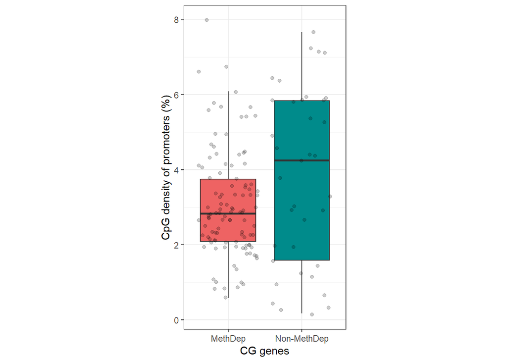

```r
# summary(methdepCT$CpG_density)
# summary(nonmethdepCT$CpG_density)

CT_genes %>%
  filter(!is.na(regulated_by_methylation)) %>%
  ggplot(aes(x = group, y = CpG_density,
             fill = group)) +
  geom_boxplot(outliers = FALSE) +
  geom_jitter(alpha = 0.2) +
  scale_fill_manual(values = MethDep_colors) +
  theme_bw() +
  ylab("CpG density of promoters (%)") +
  xlab("CG genes") +
  theme(legend.position = "none",
        aspect.ratio = 2)
```

Boxplot show that there is more variance for Non-MethDep genes. Is there a statistically significant difference ?

First I have to check the data normality to know what test to do.

```r
shapiro.test(methdepCT$CpG_density)
```

```
##
##  Shapiro-Wilk normality test
##
## data:  methdepCT$CpG_density
## W = 0.94553, p-value = 0.0002389
```

```r
shapiro.test(nonmethdepCT$CpG_density)
```

```
##
##  Shapiro-Wilk normality test
##
## data:  nonmethdepCT$CpG_density
## W = 0.93521, p-value = 0.03255
```

p value is significative for both so we reject normality of the data

Use a Wilcoxon test to compare distributions as they are not normal and few observations.

```r
wilcox.test(methdepCT$CpG_density, nonmethdepCT$CpG_density)
```

```
##
##  Wilcoxon rank sum test with continuity correction
##
## data:  methdepCT$CpG_density and nonmethdepCT$CpG_density
## W = 1620.5, p-value = 0.08719
## alternative hypothesis: true location shift is not equal to 0
```

The pvalue testing the difference between the distributions is not significative, we can’t say that there’s a difference between those two distributions. There’s then no statistically significative difference between those two distributions and the CpG density of promoters that are MethDep and Non-MethDep.

# Review 3.4

*It may be interesting to investigate the evolutionary track of these CG genes, particularly the X-linked Methdep ones, as they tend to be organized as family gene clusters. How much are they conserved, are they primate/hominoid-specific ?*

Question is then, how much are the X-linked MethDep CT conserved through evolution? For that, I need to find the tools to be able to compare MethDep and non MethDep and see if MethDep are more conserved before the others, if some are more recent. I need different species that recapitulate evolution.

Those are the genes I analyse and the species I’m using.

```r
gene_names <- all_genes$external_gene_name

all_genes <- all_genes %>%
  mutate(group = case_when(CT_gene_type == "CT_gene" & regulated_by_methylation & X_linked ~ "X-linked Methdep CG",
                           CT_gene_type == "CT_gene" & regulated_by_methylation & !X_linked ~ "Not X Methdep CG",
                           CT_gene_type == "CT_gene" & !regulated_by_methylation ~ "Non-Methdep CG",
                           CT_gene_type == "other" & X_linked ~ "X-linked other",
                           CT_gene_type == "other" & !X_linked & chr != "Y" ~ "Autosomal other"))

table(all_genes$group, useNA = "ifany")
```

```
##
##     Autosomal other      Non-Methdep CG    Not X Methdep CG X-linked Methdep CG
##               23247                  37                  39                  69
##      X-linked other                <NA>
##                 886                 210
```

```r
n_in_group <- table(all_genes$group, useNA = "ifany") %>%
  data.frame() %>%
  dplyr::rename("group" = "Var1", "n_in_group" = "Freq")

species <- c("mmusculus",  # mouse
             "mmulatta",   # macaque
             "ggorilla", # gorilla
             "ptroglodytes", # chimp
             "clfamiliaris",  # dog
             "ggallus",    # chicken
             "drerio",      # zebrafish
             "dmelanogaster", # drosophilia
             "xtropicalis", # Xenope frog
             "celegans") # worm
species
```

```
##  [1] "mmusculus"     "mmulatta"      "ggorilla"      "ptroglodytes"
##  [5] "clfamiliaris"  "ggallus"       "drerio"        "dmelanogaster"
##  [9] "xtropicalis"   "celegans"
```

Ensembl database has information about orthologs and evolution, I can access and manipulate those using BiomaRt.

```r
ensembl <- useMart("ensembl", dataset = "hsapiens_gene_ensembl")

# To see what I want to get from ensembl, see here
# View(listAttributes(ensembl))
# I chose the attributes I wanted there

# I want a table per specie

for (specie in species) {
  attributes <- c("external_gene_name", "ensembl_gene_id",
                  paste0(specie, "_homolog_ensembl_gene"), # gene stable id
                  paste0(specie, "_homolog_associated_gene_name"), # gene name
                  paste0(specie, "_homolog_subtype"), # last common ancestor
                  paste0(specie, "_homolog_orthology_type"), # homology type
                  paste0(specie, "_homolog_perc_id"), # %id. target species gene identical to query gene
                  paste0(specie, "_homolog_orthology_confidence")) # orthology confidence [0 low, 1 high]

  tmp <-  getBM(attributes = attributes,
                filters = "external_gene_name",
                values = gene_names,
                mart = ensembl)

colnames(tmp) <- c("external_gene_name", "ensembl_gene_id",
                  "homolog_ensembl_gene","homolog_associated_gene_name",
                  "homolog_subtype", "homolog_orthology_type", "homolog_perc_id",
                  "homolog_orthology_confidence")
  tmp <- tmp %>%
    filter(!is.na(homolog_perc_id)) %>% # to keep only when ortholog found
    mutate(species = specie)
  assign(paste0(specie, "_orthologs"), tmp)
}
```

What does these data look like ? Example with the mouse here.

```r
mmusculus_orthologs
```

| external_gene_name | ensembl_gene_id | homolog_ensembl_gene | homolog_associated_gene_name | homolog_subtype | homolog_orthology_type | homolog_perc_id | homolog_orthology_confidence | species |
| --- | --- | --- | --- | --- | --- | --- | --- | --- |
| WNT7A | ENSG00000154764 | ENSMUSG00000030093 | Wnt7a | Euarchontoglires | ortholog_one2one | 99.42690 | 1 | mmusculus |
| CHL1 | ENSG00000134121 | ENSMUSG00000030077 | Chl1 | Euarchontoglires | ortholog_one2one | 83.74180 | 1 | mmusculus |
| C3orf20 | ENSG00000131379 | ENSMUSG00000034063 | 4930590J08Rik | Euarchontoglires | ortholog_one2one | 64.38050 | 1 | mmusculus |
| EFHB | ENSG00000163576 | ENSMUSG00000023931 | Efhb | Euarchontoglires | ortholog_one2one | 68.78750 | 1 | mmusculus |
| PP2D1 | ENSG00000183977 | ENSMUSG00000044957 | Pp2d1 | Euarchontoglires | ortholog_one2one | 55.55560 | 1 | mmusculus |
| SYN2 | ENSG00000157152 | ENSMUSG00000009394 | Syn2 | Euarchontoglires | ortholog_one2one | 95.18900 | 1 | mmusculus |
| SLC22A13 | ENSG00000172940 | ENSMUSG00000074028 | Slc22a13 | Euarchontoglires | ortholog_one2many | 73.32120 | 1 | mmusculus |
| SLC22A13 | ENSG00000172940 | ENSMUSG00000092212 | Slc22a13b | Euarchontoglires | ortholog_one2many | 72.95830 | 1 | mmusculus |
| PTPRG | ENSG00000144724 | ENSMUSG00000121513 | Ptprg | Amniota | ortholog_one2one | 94.18690 | 1 | mmusculus |
| KBTBD8 | ENSG00000163376 | ENSMUSG00000030031 | Kbtbd8 | Euarchontoglires | ortholog_one2one | 97.33780 | 1 | mmusculus |

[output cut: 9990 more lines]

All genes can be represented numerous times as they can have a multitude of orthologs, with more or less confidence and identity. Here are the number of genes for which there is at least one ortholog and the number of genes that have confident orthologs.

```r
mmusculus_orthologs %>%
  pull(external_gene_name) %>%
  unique() %>%
  length()
```

```
## [1] 17511
```

```r
mmusculus_orthologs %>%
  filter(homolog_orthology_confidence == 1) %>%
  filter(!duplicated(external_gene_name)) %>%
  nrow()
```

```
## [1] 16419
```

In order to visualise those results and compare species, I want to know what percentage of each group of genes has orthologs in each specie.

```r
species_data <- list(mmusculus_orthologs, mmulatta_orthologs, ggorilla_orthologs,
                     ptroglodytes_orthologs,clfamiliaris_orthologs,
                     ggallus_orthologs, drerio_orthologs, dmelanogaster_orthologs,
                     xtropicalis_orthologs, celegans_orthologs)

# I want a table with one line per gene found in each specie
all_orthologs <- tibble()

for (i in 1:length(species_data)) {
  # First I want to make sure I'm keeping a confident one where there is
  tmp1 <- species_data[[i]] %>%
    group_by(external_gene_name) %>%
    filter(homolog_orthology_confidence == "1") %>% # keeps the confident one if there is one
    ungroup() %>%
    filter(!duplicated(external_gene_name)) # keeps only one if same %

  # Then I keep the max % when it's not confident
  # (when just doing this, the duplicated filter was removing confident ones)
  tmp2 <- species_data[[i]] %>%
    filter(!external_gene_name %in% tmp1$external_gene_name) %>%
    group_by(external_gene_name) %>%
    filter(homolog_perc_id == max(homolog_perc_id)) %>% # keeps the more alike
    ungroup() %>%
    filter(!duplicated(external_gene_name))

  tmp <- rbind(tmp1, tmp2)

  all_orthologs <- rbind(all_orthologs, tmp)
}

all_orthologs
```

| external_gene_name | ensembl_gene_id | homolog_ensembl_gene | homolog_associated_gene_name | homolog_subtype | homolog_orthology_type | homolog_perc_id | homolog_orthology_confidence | species |
| --- | --- | --- | --- | --- | --- | --- | --- | --- |
| WNT7A | ENSG00000154764 | ENSMUSG00000030093 | Wnt7a | Euarchontoglires | ortholog_one2one | 99.4269 | 1 | mmusculus |
| CHL1 | ENSG00000134121 | ENSMUSG00000030077 | Chl1 | Euarchontoglires | ortholog_one2one | 83.7418 | 1 | mmusculus |
| C3orf20 | ENSG00000131379 | ENSMUSG00000034063 | 4930590J08Rik | Euarchontoglires | ortholog_one2one | 64.3805 | 1 | mmusculus |
| EFHB | ENSG00000163576 | ENSMUSG00000023931 | Efhb | Euarchontoglires | ortholog_one2one | 68.7875 | 1 | mmusculus |
| PP2D1 | ENSG00000183977 | ENSMUSG00000044957 | Pp2d1 | Euarchontoglires | ortholog_one2one | 55.5556 | 1 | mmusculus |
| SYN2 | ENSG00000157152 | ENSMUSG00000009394 | Syn2 | Euarchontoglires | ortholog_one2one | 95.1890 | 1 | mmusculus |
| SLC22A13 | ENSG00000172940 | ENSMUSG00000074028 | Slc22a13 | Euarchontoglires | ortholog_one2many | 73.3212 | 1 | mmusculus |
| PTPRG | ENSG00000144724 | ENSMUSG00000121513 | Ptprg | Amniota | ortholog_one2one | 94.1869 | 1 | mmusculus |
| KBTBD8 | ENSG00000163376 | ENSMUSG00000030031 | Kbtbd8 | Euarchontoglires | ortholog_one2one | 97.3378 | 1 | mmusculus |
| PDZRN3 | ENSG00000121440 | ENSMUSG00000035357 | Pdzrn3 | Eutheria | ortholog_one2one | 94.5591 | 1 | mmusculus |

[output cut: 9990 more lines]

The table here contains one line per gene in each specie, either the high confidence one or the maximum percentage of id.

```r
all_orthologs_total_n <- all_orthologs %>%
  left_join(dplyr::select(all_genes, external_gene_name, group)) %>%
  filter(!is.na(group)) %>%
  group_by(species, group) %>%
  summarise(n_total_in_specie = n())

all_orthologs_highconf_n <- all_orthologs %>%
  filter(homolog_orthology_confidence == "1") %>%
  left_join(dplyr::select(all_genes, external_gene_name, group)) %>%
  filter(!is.na(group)) %>%
  group_by(species, group) %>%
  summarise(n_highconf_in_specie = n())

all_orthologs_lowconf_n <- all_orthologs %>%
  filter(homolog_orthology_confidence == "0") %>%
  left_join(dplyr::select(all_genes, external_gene_name, group)) %>%
  filter(!is.na(group)) %>%
  group_by(species, group) %>%
  summarise(n_lowconf_in_specie = n())

all_orthologs_perc <- all_orthologs_total_n %>%
  left_join(all_orthologs_highconf_n) %>%
  left_join(all_orthologs_lowconf_n) %>%
  left_join(n_in_group) %>%
  mutate(total_percentage_in_specie = n_total_in_specie/n_in_group * 100,
         highconf_percentage_in_specie = n_highconf_in_specie/n_in_group * 100,
         lowconf_percentage_in_specie = n_lowconf_in_specie/n_in_group * 100) %>%
  mutate(group = factor(group, levels = c("Autosomal other", "X-linked other",
                                          "Non-Methdep CG", "Not X Methdep CG",
                                          "X-linked Methdep CG"))) %>%
  mutate(species = factor(species, levels = c("ptroglodytes", "mmulatta", "ggorilla",
                                              "clfamiliaris", "mmusculus",
                                              "ggallus", "xtropicalis", "drerio",
                                              "dmelanogaster", "celegans")))

all_orthologs_perc
```

| species | group | n_total_in_specie | n_highconf_in_specie | n_lowconf_in_specie | n_in_group | total_percentage_in_specie | highconf_percentage_in_specie | lowconf_percentage_in_specie |
| --- | --- | --- | --- | --- | --- | --- | --- | --- |
| celegans | Autosomal other | 7612 | 2401 | 5211 | 23247 | 32.744010 | 10.328214 | 22.415796 |
| celegans | Non-Methdep CG | 11 | NA | 11 | 37 | 29.729730 | NA | 29.729730 |
| celegans | Not X Methdep CG | 3 | NA | 3 | 39 | 7.692308 | NA | 7.692308 |
| celegans | X-linked Methdep CG | 17 | NA | 17 | 69 | 24.637681 | NA | 24.637681 |
| celegans | X-linked other | 294 | 77 | 217 | 886 | 33.182844 | 8.690745 | 24.492099 |
| clfamiliaris | Autosomal other | 16221 | 13712 | 2509 | 23247 | 69.776745 | 58.983955 | 10.792790 |
| clfamiliaris | Non-Methdep CG | 17 | 10 | 7 | 37 | 45.945946 | 27.027027 | 18.918919 |
| clfamiliaris | Not X Methdep CG | 14 | 9 | 5 | 39 | 35.897436 | 23.076923 | 12.820513 |
| clfamiliaris | X-linked Methdep CG | 47 | 2 | 45 | 69 | 68.115942 | 2.898551 | 65.217391 |
| clfamiliaris | X-linked other | 623 | 429 | 194 | 886 | 70.316027 | 48.419865 | 21.896163 |

[output cut: 40 more lines]

I can use this table to do a visualisation.

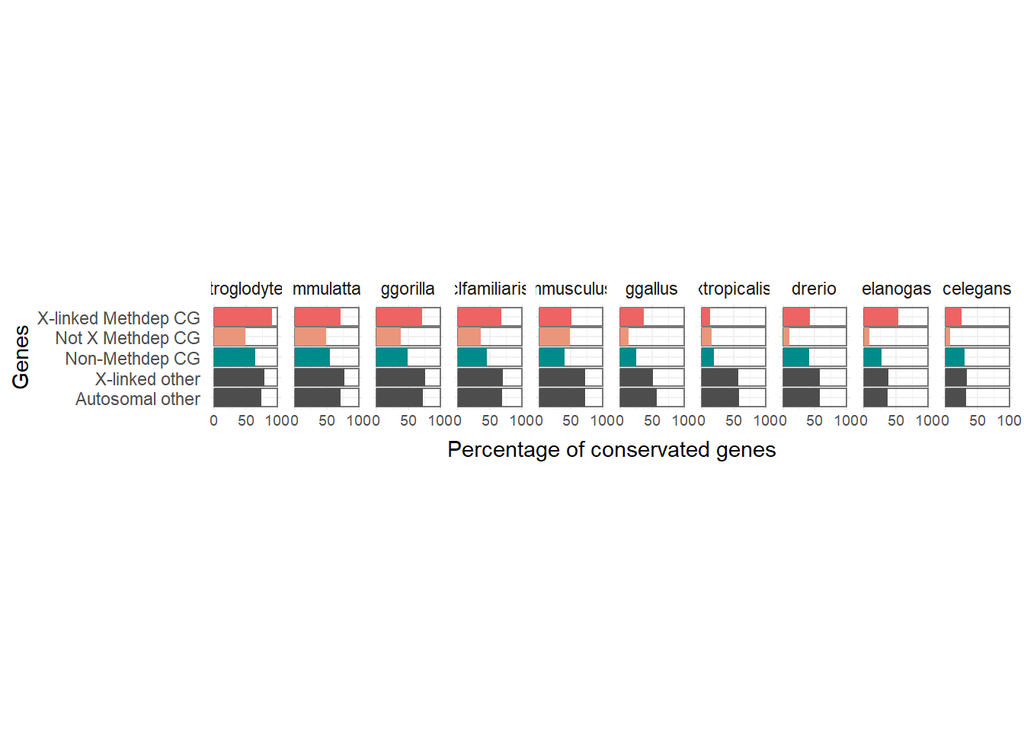

```r
all_orthologs_perc %>%
  ggplot(aes(x = total_percentage_in_specie, y = group, fill = group)) +
  geom_col(aes(x = 100), fill = "white", color = "grey47", alpha = 0.3)+
  geom_col() +
  scale_fill_manual(values = all_groups_colors) +
  facet_grid(~species) +
  theme_minimal() +
  ylab("Genes") +
  xlab("Percentage of conservated genes") +
  theme(legend.position = "none",
        aspect.ratio = 1.5,
        axis.text.x = element_text(angle = 0,
                                   size = 7,
                                   vjust = 3)) +
  scale_x_continuous(breaks = c(0, 50, 100))
```

We can see that, for mmusculus, X-linked CG genes are way less conserved than all others X-linked. MethDep CT genes seems to be quite specific to primates.

I can do it again but only keeping the species that are the most interesting.

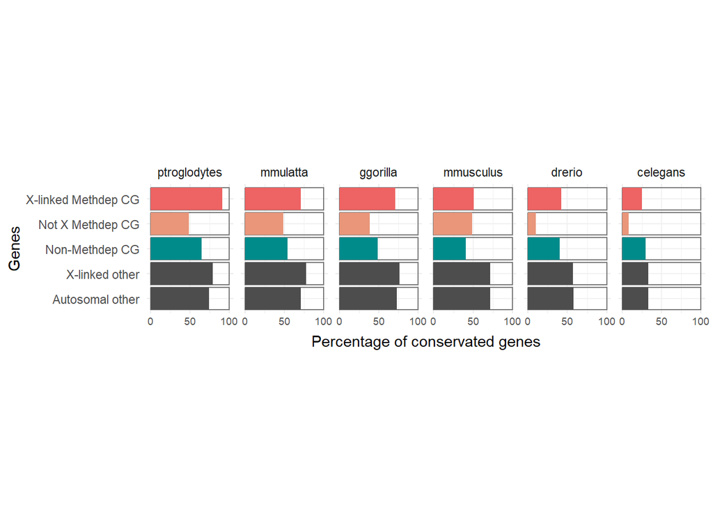

```r
all_orthologs_perc %>%
  filter(!species %in% c("clfamiliaris", "ggallus", "xtropicalis", "dmelanogaster")) %>%
  ggplot(aes(x = total_percentage_in_specie, y = group, fill = group)) +
  geom_col(aes(x = 100), fill = "white", color = "grey47", alpha = 0.3)+
  geom_col() +
  scale_fill_manual(values = all_groups_colors) +
  facet_grid(~species) +
  theme_minimal() +
  ylab("Genes") +
  xlab("Percentage of conservated genes") +
  theme(legend.position = "none",
        aspect.ratio = 1.5,
        axis.text.x = element_text(angle = 0,
                                   size = 7,
                                   vjust = 3)) +
  scale_x_continuous(breaks = c(0, 50, 100))
```

I can do the same thing but highlighting the amount of genes that has a confident homolog (in dark) or not (in light).

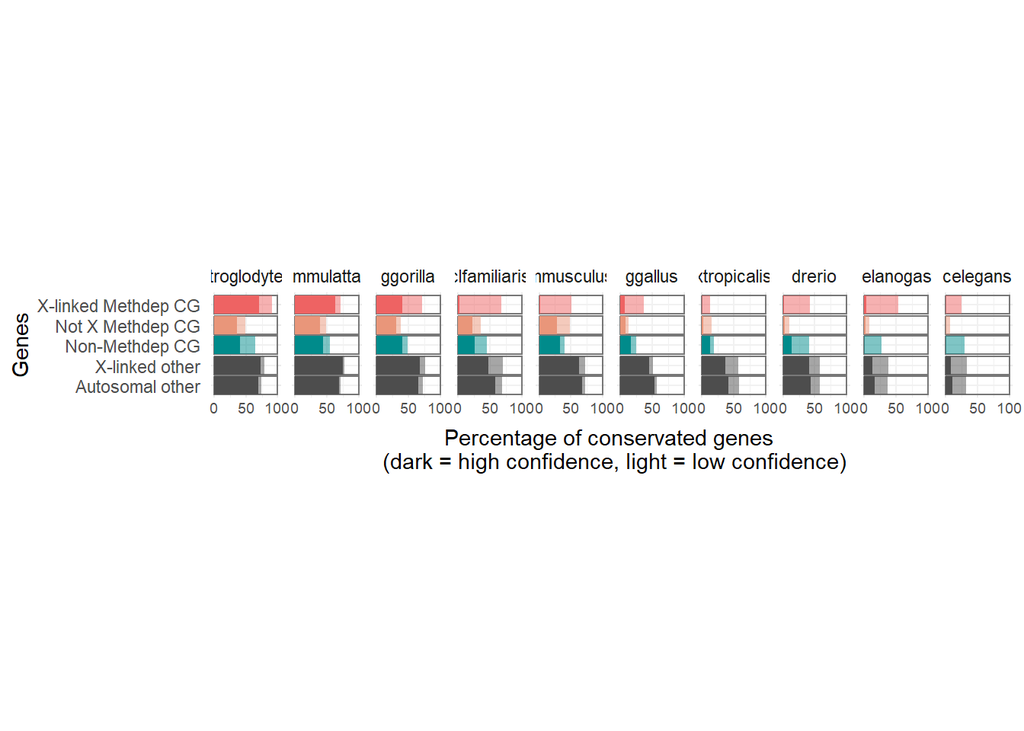

```r
all_orthologs_perc %>%
  ggplot(aes(y = group, fill = group)) +
  geom_col(aes(x = 100), fill = "white", color = "grey47", alpha = 0.3) +
  geom_col(aes(x = total_percentage_in_specie), alpha = 0.5) +
  geom_col(aes(x = highconf_percentage_in_specie)) +
  scale_fill_manual(values = all_groups_colors) +
  facet_grid(~species) +
  theme_minimal() +
  ylab("Genes") +
   xlab("Percentage of conservated genes \n (dark = high confidence, light = low confidence)") +
  theme(legend.position = "none",
        aspect.ratio = 1.5,
        axis.text.x = element_text(angle = 0,
                                   size = 7,
                                   vjust = 3)) +
  scale_x_continuous(breaks = c(0, 50, 100))
```

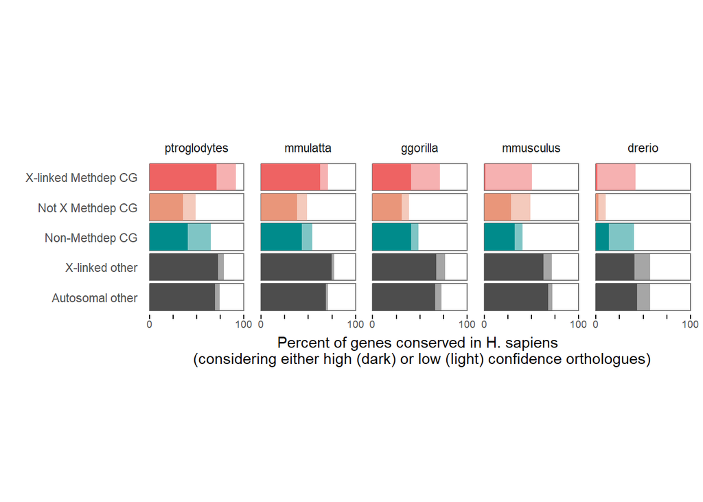

```r
all_orthologs_perc %>%
  filter(!species %in% c("clfamiliaris", "ggallus", "xtropicalis", "dmelanogaster", "celegans")) %>%
  ggplot(aes(y = group, fill = group)) +
  geom_col(aes(x = 100), fill = "white", color = "grey47", alpha = 0.3) +
  geom_col(aes(x = total_percentage_in_specie), alpha = 0.5) +
  geom_col(aes(x = highconf_percentage_in_specie)) +
  scale_fill_manual(values = all_groups_colors) +
  facet_grid(~species) +
  theme_minimal() +
  ylab("") +
  xlab("Percent of genes conserved in H. sapiens \n (considering either high (dark) or low (light) confidence orthologues)") +
  theme(legend.position = "none",
        aspect.ratio = 1.5,
        axis.text.x = element_text(angle = 0,
                                   size = 7,
                                   vjust = 2),
        panel.grid.major = element_blank(),
        panel.grid.minor = element_blank(),
        axis.ticks.x = element_line(size = 0.4)) +
  scale_x_continuous(limits = c(0, 100), labels = c("0","", "", "", "100"))
```

Seems like something evolved in primates using imprinting.

# Review 3.5

*And for the ones that are present in the mouse genome, it would be interesting to assess whether there is conservation of their male-specific expression in germ cells (versus female germ cells) and female-specific expression in embryos (versus male embryos).*

Question is then, is it conserved in mouse to have male specificity? This could hint towards mice study. This has to be looked at in pre implanted embryo and in gametogenesis, to have a comparative analysis between male and female.

The answers found at the previous question, showing there isn’t really a conservation of those genes in the mice as the sex biased genes are mostly human specific. Other elements of answer are more detailed in Axelle’s review